# Galamsey event study — Q1 (part 1): upstream mining → downstream vegetation (C&S mbar sweep)

Sree Ayyar, Till Meissner

13 Juli 2026

This document **implements Q1** of the three-part event-study battery specified in `event_study_design.md`, **rebuilt 2026-07-09** to the clean two-estimator structure of its Q0 sibling `a_05_event_study_1.Rmd`. The sprawling V1 (TWFE distributed-lag) / V3 / V3b machinery of the previous version is gone; what remains are the **two estimators Q0 uses** — now split across two files so each knits in its own R session:

- `a_05_event_study_1.Rmd` — **Q0**: own-hex mining → own-hex vegetation (mechanics sanity check; read that one first).
- **`a_05_event_study_2.Rmd`** (this file) — **Q1 part 1**: upstream mining → downstream vegetation, **Callaway & Sant’Anna mbar sweep**. Companion `a_05_event_study_2b.Rmd` runs the **dCDH continuous-dose** robustness for the same exposure families × two routings.
- `a_05_event_study_3.Rmd` — **Q2**: neighbour mining → own mining.

**Q1 — Waterborne degradation.** Outcome = downstream peak vegetation; treatment = **upstream** mining; the directed flow graph supplies the neighbour definitions; downstream onset is the directional placebo.

**Two estimators (mirroring Q0), split across two files** (2026-07-09 — chaining them in one session exhausted memory: `did_multiplegt_dyn` runs on polars/Rust and OOMs at 2 km after this file’s ~80 C&S bootstrap fits):

1. **Callaway & Sant’Anna — absorbing treatment at a stock threshold** (the headline; **this file**). Treatment clock = first year the exposure’s mining **stock** crosses $\bar m$, swept over `mbar_grid = c(0, 5, 10, 20)` ha. `did::att_gt` → `aggte(type="dynamic")`, not-yet-treated controls, DR estimator.
2. **dCDH — continuous dose** (`did_multiplegt_dyn`, de Chaisemartin & D’Haultfœuille) — moved to `a_05_event_study_2b.Rmd`. Treats the exposure stock as a continuous treatment intensity rather than discretising it at a threshold — robustness against the threshold choice.

**Two dimensions swept through both estimators:**

- **Five directed exposures** (treatment → comparison → placebo): all-reachable upstream, upstream 1-hop, **lateral** (queen-adjacent minus the 1-hop up/down hexes — the off-flow comparison, *not* plain queen adjacency, which would mix upstream + lateral + downstream), downstream 1-hop, and all-reachable downstream.
- **Two routing cut-offs.** The MERIT D8 flow graph is built at two minimum-upstream-drainage-area thresholds: **ROUTE_KM2 = 10** (the primary graph — unsuffixed columns) and **ROUTE_KM2 = 50** (a coarser routing that keeps only larger streams — `_upa50`-suffixed columns). Every exposure is run at **both**, so the whole battery answers “does the result survive changing which channels count as rivers?” (This wires in the alt `_upa50` flow graph that `b_03c`/`b_03d` have long produced but no Q1 design previously used — see `event_study_design.md`.)

Restricted (2026-07-09, at the user’s request, to keep the fit count in check) to **EVI peak (annual max)** only, over just two masks: **`veg_narrow`** (the “productive green” mask — dense cropland ∪ tree cover) and **`no-mine-crop`** (pixels never classified as Barenblitt mining — isolates spillover onto surrounding land from the mechanical on-mine VI collapse). SEs clustered on real HydroBASINS level-9 sub-basins (`basin_num`; falls back to a 25 km centroid-block stand-in if absent — see `load-panel`).

# 1 Conceptual framework — neighbour definitions

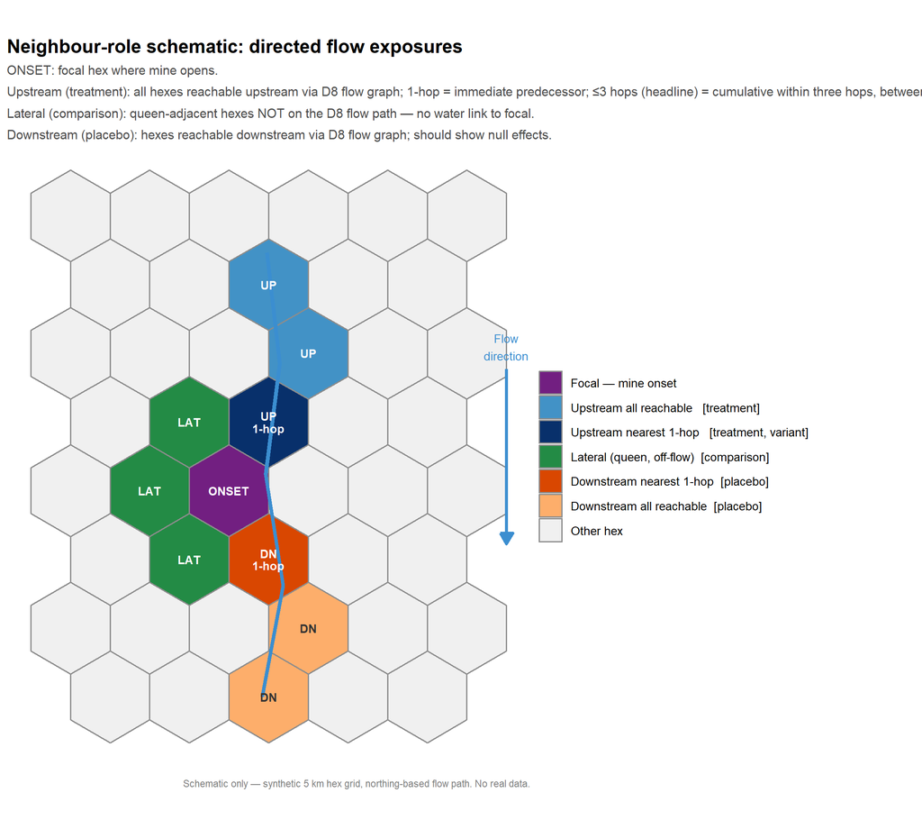

# 2 Data foundations

```r
es <- readRDS(here("data", "processed", sprintf("event_panel_%dkm.rds", params$resolution_km)))
panel  <- es$panel
hex_sf <- es$hex_sf

# Spatial clustering key: real HydroBASINS level-9 sub-basins (basin_id/basin_num from
# d_07_hydrobasins.R via b_03e) when present, else the 25 km centroid-block stand-in. Aliased onto
# block_id/block_num so downstream code (run_cs clustervars = "block_num") needs one name only.
has_basin <- all(c("basin_id", "basin_num") %in% names(panel)) && !all(is.na(panel$basin_num))
if (has_basin) {
  panel <- panel |> mutate(block_id = as.character(basin_id), block_num = basin_num)
  message(sprintf("Clustering on %d HydroBASINS level-9 sub-basins (basin_num).",
                  n_distinct(panel$block_num)))
} else {
  warning("basin_id/basin_num not found in this panel -- falling back to the 25 km centroid-block ",
          "SE-clustering stand-in. Run d_07_hydrobasins.R then b_03e_assemble_eventpanel.R for ",
          "this resolution to get real sub-basin clustering.")
  cent   <- sf::st_coordinates(suppressWarnings(sf::st_centroid(sf::st_geometry(hex_sf))))
  blocks <- tibble(hex_id = hex_sf$hex_id,
                   block_id = paste0("b_", round(cent[, 1] / 25000), "_", round(cent[, 2] / 25000)))
  panel  <- left_join(panel, blocks, by = "hex_id") |>
    mutate(block_num = as.integer(factor(block_id)))
}

has_upstream <- !all(is.na(panel$up_onset_year))
has_terrain  <- all(c("elev_mean", "slope_mean") %in% names(panel)) && !all(is.na(panel$elev_mean))
xf <- if (has_terrain) ~ elev_mean + slope_mean else ~ 1

c(upstream_columns_present   = has_upstream,
  terrain_covariates_present = has_terrain,
  hydrobasins_clustering     = has_basin,
  n_clusters                 = n_distinct(panel$block_num))
```

```
##   upstream_columns_present terrain_covariates_present
##                          1                          1
##     hydrobasins_clustering                 n_clusters
##                          1                        287
```

```r
# Cumulative "within 3 hops" flow exposure = sum of the three DISJOINT rings (ring 1 = nearest_*,
# plus hop2 + hop3), built for both routings when the ring columns exist. Motivation: at higher
# mbar the treatment clock is set by the aggregate of the three hexes rather than ring 1 alone --
# at mbar = 20 ha only 27.5% of within-3 onsets are set by ring 1, and 35% of treated hexes are
# invisible to the 1-hop definition (diagnostic in event_study_design.md's hop-ring note). The
# three ring stock columns share one NA pattern (same flow graph), so a plain rowSums propagates
# the off-graph NA correctly; le3 onset = earliest ring onset (pmin). up_le3 = treatment,
# down_le3 = symmetric placebo. Adding these two columns is all that's needed -- resolve_exposures()
# and the whole C&S sweep pick them up from the EXPOSURES table below.
add_le3 <- function(df, dir, suffix) {
  stem   <- c(sprintf("nearest_%s", dir), sprintf("%s_hop2", dir), sprintf("%s_hop3", dir))
  cols_s <- paste0(stem, "_stock_ha",   suffix)
  cols_o <- paste0(stem, "_onset_year", suffix)
  if (!all(cols_s %in% names(df))) return(df)   # rings not built for this routing/resolution
  df[[paste0(dir, "_le3_stock_ha", suffix)]] <- rowSums(df[cols_s])                # NA-propagating
  onset <- suppressWarnings(do.call(pmin, c(df[cols_o], na.rm = TRUE)))            # earliest ring onset
  onset[is.infinite(onset)] <- NA_real_                                           # never-onset -> NA (pmin gives Inf)
  df[[paste0(dir, "_le3_onset_year", suffix)]] <- as.integer(onset)
  df
}
for (S in c("", "_upa50")) for (d in c("up", "down")) panel <- add_le3(panel, d, S)

c(up_le3_present   = "up_le3_stock_ha"   %in% names(panel),
  down_le3_present = "down_le3_stock_ha" %in% names(panel))
```

```
##   up_le3_present down_le3_present
##            FALSE            FALSE
```

```r
# Restricted 2026-07-09 to EVI peak (annual max) only, over two masks: veg_narrow (the "productive
# green" mask -- dense cropland ∪ tree cover, from b_03a_vi_panel.R's CCI_MASKS) and no-mine-crop
# (pixels never classified as Barenblitt mining). EVI-only + 2 masks keeps the 2-routing x 7-exposure
# x 4-mbar C&S sweep tractable. veg_narrow is listed first and is the headline.
OUTCOMES <- c(
  evi_modis_veg_narrow_max = "EVI (peak, veg-narrow)",
  evi_modis_nominecrop_max = "EVI (peak, no-mine-crop)"
)
OUTCOMES <- OUTCOMES[names(OUTCOMES) %in% names(panel)]
OUTCOMES <- OUTCOMES[vapply(names(OUTCOMES), \(c) !all(is.na(panel[[c]])), logical(1))]

# NA share of each retained outcome (both are low-NA masks: no-mine-crop ~0.1%, veg_narrow a usable
# middle mask -- see event_study_design.md's missingness note).
tibble(outcome  = unname(OUTCOMES),
       na_share = vapply(names(OUTCOMES), \(c) mean(is.na(panel[[c]])), numeric(1))) |>
  kbl(digits = 3, caption = "Retained EVI-peak outcomes and their hex-year NA share.") |>
  kable_styling(full_width = FALSE)
```

Retained EVI-peak outcomes and their hex-year NA share.

| outcome | na_share |
| --- | --- |
| EVI (peak, veg-narrow) | 0.022 |
| EVI (peak, no-mine-crop) | 0.002 |

```r
ndvi_years   <- es$ndvi_years
mining_years <- es$mining_years
overlap_txt <- sprintf(
  "The VI stack covers %d–%d; Barenblitt mining spans %d–%d; the usable event window (their overlap) is **%d–%d**.",
  min(ndvi_years), max(ndvi_years), min(mining_years), max(mining_years),
  max(min(ndvi_years), min(mining_years)), min(max(ndvi_years), max(mining_years)))
writeLines(overlap_txt, file.path(out_es, "es_overlap_window.md"))
cat(overlap_txt)
```

The VI stack covers 2000–2025; Barenblitt mining spans 2007–2017; the usable event window (their overlap) is **2007–2017**.

## 2.1 Exposure definitions

Seven directed exposures, grouped by role. **Treatment** = mining *upstream* of the focal hex on the MERIT D8 flow graph (galamsey pollutes downstream, so upstream mining should depress the focal hex’s downstream vegetation). **Placebo** = mining *downstream* (should show no effect — water doesn’t flow uphill). **Comparison** = `lateral` (off-flow) neighbours, a land-use-adjacency control with no water link.

Each upstream/downstream role comes at three spatial radii, so the effect can be read as a function of hydrological distance:

**Caveat carried from the build:** hops are hydrological topology, so their physical length scales with the grid (~3 km at 1 km, ~15 km at 5 km) — hop-based coefficients are **not comparable across resolutions**.

```r
# Seven directed exposures, each a (stock, onset) column pair. All are flow-graph-derived and hence
# routing-dependent, so each has a "_upa50" sibling (ROUTE_KM2 = 50). Three radii per flow direction:
# 1-hop (nearest_*), cumulative <=3 hops (*_le3_*, summed from the disjoint rings in derive-le3), and
# full catchment (up_*/down_*). We deliberately use `lateral_*` (queen minus the within-3 up/down set)
# as the middle comparison group, NOT plain queen adjacency (`adj_*`) -- plain adjacency mixes
# upstream + lateral + downstream and has no _upa50 variant anyway. See event_study_design.md's V2
# note and hop-ring note.
EXPOSURES <- tibble::tribble(
  ~key,      ~stock,                  ~onset,                    ~label,                       ~role,
  "up",      "up_stock_ha",           "up_onset_year",           "upstream — all reachable",   "treatment",
  "near_up", "nearest_up_stock_ha",   "nearest_up_onset_year",   "upstream — 1-hop",           "treatment",
  "up_le3",  "up_le3_stock_ha",       "up_le3_onset_year",       "upstream — ≤3 hops",         "treatment",
  "lat",     "lateral_stock_ha",      "lateral_onset_year",      "lateral (off-flow)",         "comparison",
  "near_dn", "nearest_down_stock_ha", "nearest_down_onset_year", "downstream — 1-hop",         "placebo",
  "dn_le3",  "down_le3_stock_ha",     "down_le3_onset_year",     "downstream — ≤3 hops",       "placebo",
  "dn",      "down_stock_ha",         "down_onset_year",         "downstream — all reachable", "placebo"
)
role_lvls     <- c("treatment", "comparison", "placebo")
exposure_lvls <- EXPOSURES$label
# Palette by exposure (matches the schematic role colours: upstream = blues, lateral = green,
# downstream = oranges).
exposure_cols <- c("upstream — all reachable"   = "#4292C6",
                   "upstream — 1-hop"           = "#08306B",
                   "upstream — ≤3 hops"         = "#2171B5",
                   "lateral (off-flow)"         = "#238B45",
                   "downstream — 1-hop"         = "#D94701",
                   "downstream — ≤3 hops"       = "#F16913",
                   "downstream — all reachable" = "#FDAE6B")

# Two routing cut-offs: primary (ROUTE_KM2 = 10, unsuffixed) and alt (ROUTE_KM2 = 50, "_upa50").
ROUTINGS    <- c(upa10 = "", upa50 = "_upa50")
routing_lab <- c(upa10 = "ROUTE_KM2 = 10 (primary)", upa50 = "ROUTE_KM2 = 50 (robustness)")

# resolve_exposures(): the EXPOSURES table with columns suffixed for a routing, keeping only pairs
# whose stock column is present and not all-NA in THIS panel (upa50 columns are absent if
# hex_{N}km_flow_exposure_upa50.rds was never built).
resolve_exposures <- function(suffix) {
  EXPOSURES |>
    mutate(stock = paste0(stock, suffix), onset = paste0(onset, suffix), routing_suffix = suffix) |>
    filter(stock %in% names(panel),
           vapply(stock, \(c) !all(is.na(panel[[c]])), logical(1)))
}

# Which routings are actually available (upa50 may be absent for this resolution).
ROUTINGS_OK <- ROUTINGS[vapply(ROUTINGS, \(s) nrow(resolve_exposures(s)) > 0, logical(1))]
tibble(routing     = names(ROUTINGS_OK),
       definition  = routing_lab[names(ROUTINGS_OK)],
       n_exposures = vapply(ROUTINGS_OK, \(s) nrow(resolve_exposures(s)), integer(1))) |>
  kbl(caption = "Routing cut-offs available in this panel and how many of the 7 exposures resolve.") |>
  kable_styling(full_width = FALSE)
```

Routing cut-offs available in this panel and how many of the 7 exposures resolve.

| routing | definition | n_exposures |
| --- | --- | --- |
| upa10 | ROUTE_KM2 = 10 (primary) | 5 |
| upa50 | ROUTE_KM2 = 50 (robustness) | 5 |

```r
mbar_grid <- c(0, 5, 10, 20)    # ha thresholds for the C&S stock-threshold sweep; mbar = 0 == "any
                                # upstream mining" (onset crossing).
mbar_cols <- c(">0 ha" = "#6A3D9A", ">5 ha" = "#2171B5", ">10 ha" = "#E67E22", ">20 ha" = "#27AE60")

# C&S event-study wrapper (identical to Q0's). `gcol` = numeric col in `data` (0 = never-treated,
# else first-treat year). Returns att_gt + dynamic (event-time) + overall (group) aggregations.
run_cs <- function(data, yname, gcol, xformla = xf, cluster = "block_num",
                   control = "notyettreated", min_e = -5, max_e = 5) {
  data <- data |> filter(is.finite(.data[[yname]]))
  att <- did::att_gt(
    yname = yname, tname = "year", idname = "hex_num", gname = gcol,
    control_group = control, xformla = xformla, clustervars = cluster,
    data = as.data.frame(data), est_method = "dr",
    base_period = "universal", allow_unbalanced_panel = TRUE, bstrap = TRUE)
  list(att     = att,
       dynamic = did::aggte(att, type = "dynamic", min_e = min_e, max_e = max_e, na.rm = TRUE),
       overall = did::aggte(att, type = "group", na.rm = TRUE))
}
# tryCatch wrapper: high-mbar x sparse-exposure cells can leave too few treated units for att_gt.
# Return NULL rather than aborting the whole sweep.
safe_cs <- function(...) tryCatch(run_cs(...),
  error = function(e) { message("run_cs failed: ", conditionMessage(e)); NULL })

# first-treat column from a "stock crosses mbar" rule (0 = never crosses = C&S never-treated).
first_cross <- function(df, stock_col, mbar) {
  df |> group_by(hex_id) |>
    mutate(g_thr = { col <- .data[[stock_col]]; y <- year[!is.na(col) & col > mbar]
                     if (length(y)) min(y) else 0L }) |>
    ungroup()
}

# tidy_dyn: one C&S dynamic aggregation -> tidy event-time frame.
tidy_dyn <- function(dyn)
  tibble(event_time = dyn$egt, att = dyn$att.egt, se = dyn$se.egt) |>
  mutate(ci_lo = att - 1.96 * se, ci_hi = att + 1.96 * se)

# dyn_overlay: overlay a tidy dynamic frame's ATT paths, coloured by `group_col` (already a column
# in `df`). Used both for the exposure overlay (Q1 headline: treatment vs placebo) and the mbar
# overlay (threshold-stability robustness).
dyn_overlay <- function(df, group_col, palette, title, subtitle, legend, ylab = "ATT on EVI") {
  df <- df |> mutate(.grp = .data[[group_col]])
  ggplot(df, aes(event_time, att, colour = .grp, fill = .grp)) +
    geom_hline(yintercept = 0, linetype = "dashed", colour = "grey50") +
    geom_vline(xintercept = -0.5, linetype = "dotted", colour = "grey40") +
    geom_ribbon(aes(ymin = ci_lo, ymax = ci_hi), alpha = 0.10, colour = NA) +
    geom_line() + geom_point(size = 1.6) +
    scale_colour_manual(values = palette) + scale_fill_manual(values = palette) +
    labs(title = title, subtitle = subtitle,
         x = "Event time (years relative to treatment)", y = ylab,
         colour = legend, fill = legend) +
    theme_bw(base_size = 11)
}

# dyn_overlay_interactive: turn a dyn_overlay() ggplot into a toggleable plotly widget. ggplotly
# explodes each group into separate ribbon/line/point traces, so we re-key every trace to a shared
# legendgroup (the group token, recovered from the ggplotly trace name) and show the legend only on
# the first trace per group -- then one legend click hides/shows the whole series and a double-click
# isolates it. Returned widget is emitted with htmltools::renderTags()$html in the asis loops.
dyn_overlay_interactive <- function(p) {
  gp   <- plotly::ggplotly(p, tooltip = c("colour", "x", "y"))
  seen <- character(0)
  for (i in seq_along(gp$x$data)) {
    nm  <- gp$x$data[[i]]$name
    if (is.null(nm)) next
    grp <- sub(",.*$", "", sub("^\\(", "", nm))    # "(upstream — 1-hop,1)" -> "upstream — 1-hop"
    gp$x$data[[i]]$legendgroup <- grp
    gp$x$data[[i]]$name        <- grp
    gp$x$data[[i]]$showlegend  <- !(grp %in% seen)
    seen <- union(seen, grp)
  }
  gp
}

# show_overlay: display an overlay ggplot either as an interactive widget (HTML) or static print,
# governed by the INTERACTIVE flag. Used inside results='asis' loops, so the widget branch cat()s a
# self-contained HTML fragment (plotly.js already injected by the widget-dep chunk).
show_overlay <- function(p) {
  if (INTERACTIVE) cat(htmltools::renderTags(dyn_overlay_interactive(p))$html) else print(p)
}
```

## 2.2 Control-pool composition (own-mining contamination)

For each exposure, how many ever-exposed hexes were **already mining themselves** when the exposure fired (contaminated), vs. clean spillover cases? Reported for the primary routing (ROUTE_KM2 = 10); the `_upa50` graph reshuffles which hexes count as up/downstream but the qualitative picture is the same.

```r
cat_order <- c("Never mined themselves",
               "Started mining after exposure onset",
               "Already mining when exposure started")

pool_breakdown <- function(onset_col, label) {
  n_treated <- n_distinct(panel$hex_id[!is.na(panel[[onset_col]])])
  panel |>
    mutate(treat_onset = .data[[onset_col]]) |>
    distinct(hex_id, own_onset_year, treat_onset) |>
    filter(!is.na(treat_onset)) |>
    mutate(category = case_when(
      is.na(own_onset_year)         ~ "Never mined themselves",
      own_onset_year > treat_onset  ~ "Started mining after exposure onset",
      own_onset_year <= treat_onset ~ "Already mining when exposure started")) |>
    count(category, name = "n_hexes") |>
    mutate(n_total = n_treated, share = round(n_hexes / n_treated, 3), exposure = label) |>
    arrange(match(category, cat_order))
}

ex10 <- resolve_exposures("")
pool_combined <- bind_rows(lapply(seq_len(nrow(ex10)), \(i)
  pool_breakdown(ex10$onset[i], sprintf("%s (%s)", ex10$label[i], ex10$role[i]))))

save_md_grouped(pool_combined |> select(exposure, category, n_hexes, n_total, share),
                "es_q1_control_pool_composition.md", group_col = "exposure", digits = 3)

grp_sizes  <- pool_combined |> count(exposure) |> pull(n)
grp_labels <- pool_combined |> distinct(exposure) |> pull(exposure)
pool_combined |>
  select(exposure, category, n_hexes, n_total, share) |>
  kbl(caption = paste0(
    "Own-mining composition of ever-exposed hexes, by exposure (ROUTE_KM2 = 10). ",
    "'Never mined themselves' is the cleanest spillover sample; 'Already mining' is contaminated. ",
    "n_total = all ever-exposed hexes for that definition; share = n_hexes / n_total.")) |>
  kable_styling(full_width = FALSE) |>
  pack_rows(index = setNames(grp_sizes, grp_labels))
```

Own-mining composition of ever-exposed hexes, by exposure (ROUTE_KM2 = 10). ‘Never mined themselves’ is the cleanest spillover sample; ‘Already mining’ is contaminated. n_total = all ever-exposed hexes for that definition; share = n_hexes / n_total.

| exposure | category | n_hexes | n_total | share |
| --- | --- | --- | --- | --- |
| **upstream — all reachable (treatment)** |  |  |  |  |
| upstream — all reachable (treatment) | Never mined themselves | 1101 | 1920 | 0.573 |
| upstream — all reachable (treatment) | Started mining after exposure onset | 450 | 1920 | 0.234 |
| upstream — all reachable (treatment) | Already mining when exposure started | 369 | 1920 | 0.192 |
| **upstream — 1-hop (treatment)** |  |  |  |  |
| upstream — 1-hop (treatment) | Never mined themselves | 249 | 955 | 0.261 |
| upstream — 1-hop (treatment) | Started mining after exposure onset | 213 | 955 | 0.223 |
| upstream — 1-hop (treatment) | Already mining when exposure started | 493 | 955 | 0.516 |
| **lateral (off-flow) (comparison)** |  |  |  |  |
| lateral (off-flow) (comparison) | Never mined themselves | 808 | 1698 | 0.476 |
| lateral (off-flow) (comparison) | Started mining after exposure onset | 376 | 1698 | 0.221 |
| lateral (off-flow) (comparison) | Already mining when exposure started | 514 | 1698 | 0.303 |
| **downstream — 1-hop (placebo)** |  |  |  |  |
| downstream — 1-hop (placebo) | Never mined themselves | 444 | 1283 | 0.346 |
| downstream — 1-hop (placebo) | Started mining after exposure onset | 322 | 1283 | 0.251 |
| downstream — 1-hop (placebo) | Already mining when exposure started | 517 | 1283 | 0.403 |
| **downstream — all reachable (placebo)** |  |  |  |  |
| downstream — all reachable (placebo) | Never mined themselves | 3654 | 4679 | 0.781 |
| downstream — all reachable (placebo) | Started mining after exposure onset | 732 | 4679 | 0.156 |
| downstream — all reachable (placebo) | Already mining when exposure started | 293 | 4679 | 0.063 |

## 2.3 Treatment structure (panelviews, primary routing)

Treatment clock = first year the exposure stock crosses $\bar m$, shown for the two **upstream (treatment)** exposures at $\bar m = 0$ (any onset) and $\bar m = 20$ ha, on the headline outcome (`evi_modis_veg_narrow_max`), restricted to hexes complete over the Barenblitt window (2007–2017).

```
## Specified labels in the order of: Controls, Treated (Pre), Treated (Post).
```

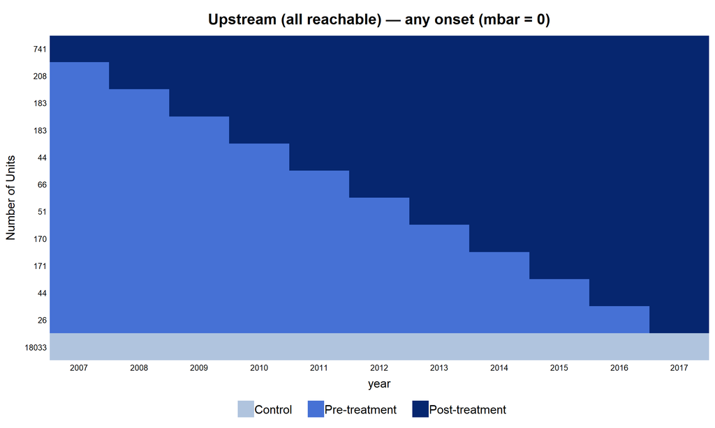

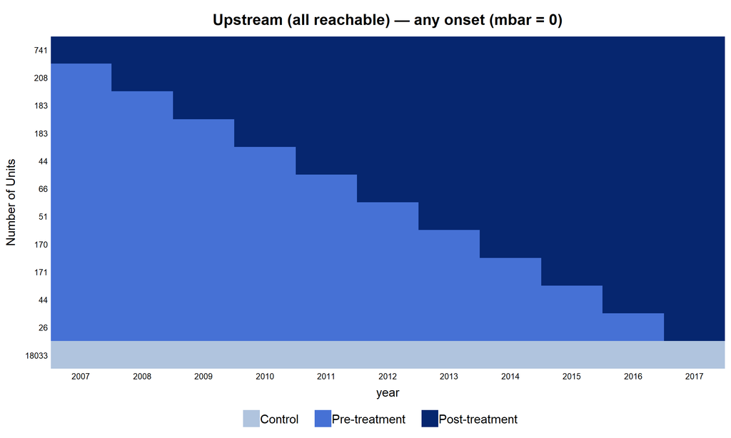

```
## Specified labels in the order of: Controls, Treated (Pre), Treated (Post).
```

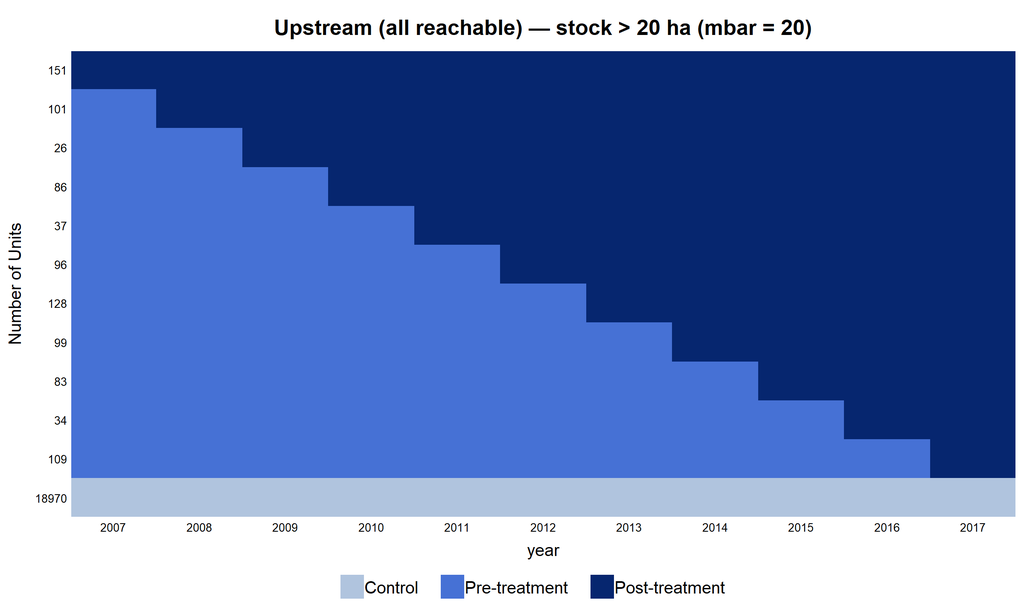

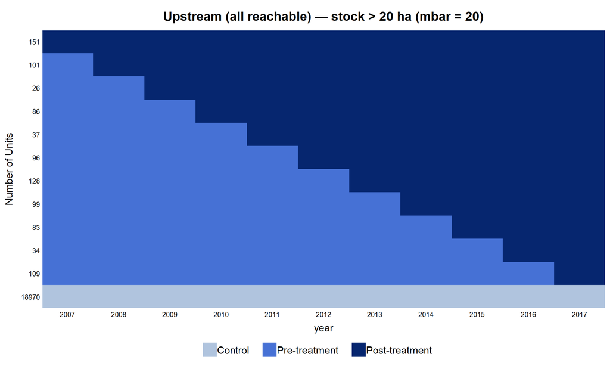

```
## Specified labels in the order of: Controls, Treated (Pre), Treated (Post).
```

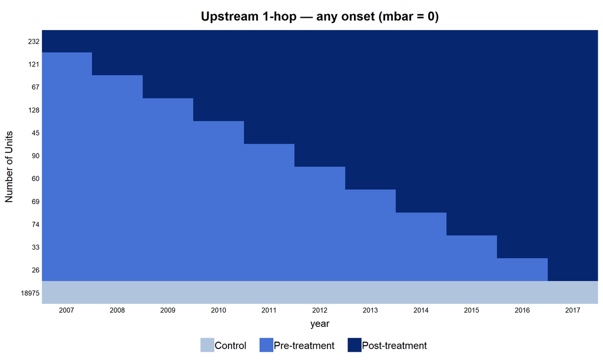

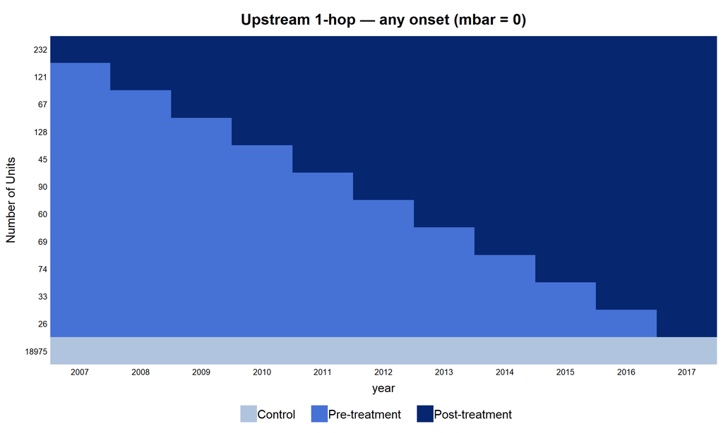

```
## Specified labels in the order of: Controls, Treated (Pre), Treated (Post).
```

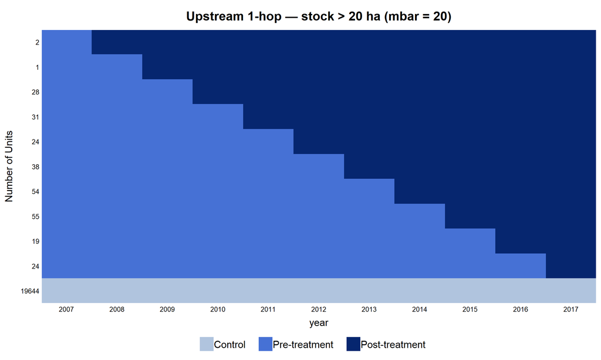

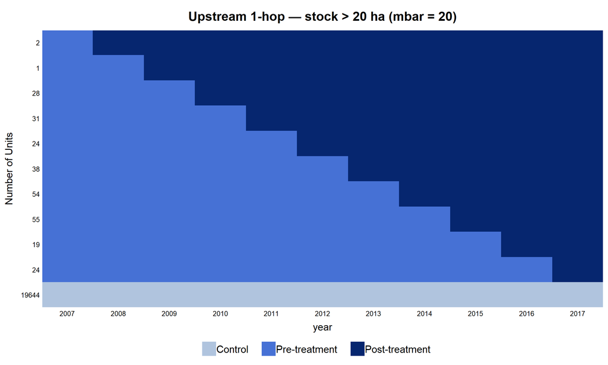

```r
pv_outcome <- names(OUTCOMES)[1]
pv_complete_ids <- panel |>
  filter(year >= 2007, year <= 2017) |>
  group_by(hex_id) |> filter(!any(is.na(.data[[pv_outcome]]))) |>
  ungroup() |> distinct(hex_id)

pv_show <- function(stock_col, mbar, main, file) {
  d <- panel |>
    filter(year >= 2007, year <= 2017) |>
    semi_join(pv_complete_ids, by = "hex_id") |>
    group_by(hex_id) |>
    mutate(g_thr = { col <- .data[[stock_col]]; y <- year[!is.na(col) & col > mbar]
                     if (length(y)) min(y) else NA_integer_ }) |>
    ungroup() |>
    mutate(D = as.integer(!is.na(g_thr) & year >= g_thr))
  p <- panelview(as.formula(paste(pv_outcome, "~ D")), data = d, index = c("hex_id", "year"),
                 main = main, legend.labs = c("Control", "Pre-treatment", "Post-treatment"),
                 pre.post = TRUE, by.timing = TRUE, collapse.history = TRUE,
                 display.all = TRUE, report.missing = FALSE, background = "white")
  print(p); save_es(p, file, width = 10, height = 6); invisible(p)
}

pv_specs <- list(
  list("up_stock_ha",         0,  "Upstream (all reachable) — any onset (mbar = 0)",      "es_q1_panelview_up_mbar0.png"),
  list("up_stock_ha",         20, "Upstream (all reachable) — stock > 20 ha (mbar = 20)", "es_q1_panelview_up_mbar20.png"),
  list("nearest_up_stock_ha", 0,  "Upstream 1-hop — any onset (mbar = 0)",                "es_q1_panelview_nearup_mbar0.png"),
  list("nearest_up_stock_ha", 20, "Upstream 1-hop — stock > 20 ha (mbar = 20)",           "es_q1_panelview_nearup_mbar20.png"))
pv_specs <- Filter(\(s) s[[1]] %in% names(panel) && !all(is.na(panel[[s[[1]]]])), pv_specs)
for (s in pv_specs) pv_show(s[[1]], s[[2]], s[[3]], s[[4]])
```

# 3 Control variables in the C&S estimator

`did::att_gt` uses `xformla` in both legs of the doubly-robust (DR) estimator: the propensity-score model (what predicts a hex’s treatment cohort) and the outcome regression (what predicts EVI conditional on pre-treatment covariates). DR is consistent if *either* leg is correctly specified.

**Currently used:** `xf = ~ elev_mean + slope_mean` (or `~ 1` when terrain is absent) — topographic accessibility (high, steep terrain is harder to mine and has systematically different vegetation).

# 4 Estimator 1 — Callaway & Sant’Anna (absorbing treatment, mbar sweep)

```r
# Compute every C&S fit once (routing x exposure x outcome x mbar), storing only the tidy dynamic
# frame + overall ATT row per cell. safe_cs() returns NULL for cells too sparse to fit; those are
# dropped. Fit count = length(ROUTINGS_OK) x n_exposures x length(OUTCOMES) x length(mbar_grid).
cs_dyn <- list(); cs_ovr <- list()
for (rt in names(ROUTINGS_OK)) {
  ex <- resolve_exposures(ROUTINGS_OK[[rt]])
  for (i in seq_len(nrow(ex))) for (oc in names(OUTCOMES)) for (mb in mbar_grid) {
    fit <- safe_cs(first_cross(panel, ex$stock[i], mb), oc, "g_thr")
    if (is.null(fit)) next
    key  <- paste(rt, ex$key[i], oc, mb, sep = "|")
    meta <- list(routing = rt, exposure = ex$label[i], role = ex$role[i],
                 outcome = oc, outcome_lab = OUTCOMES[[oc]], mbar = mb)
    cs_dyn[[key]] <- tidy_dyn(fit$dynamic) |> mutate(!!!meta)
    cs_ovr[[key]] <- tibble(!!!meta, att = fit$overall$overall.att, se = fit$overall$overall.se)
  }
}
cs_dyn_all <- bind_rows(cs_dyn) |>
  mutate(exposure = factor(exposure, levels = exposure_lvls),
         role     = factor(role, levels = role_lvls),
         mbar_lab = factor(paste0(">", mbar, " ha"), levels = names(mbar_cols)))
cs_ovr_all <- bind_rows(cs_ovr) |>
  mutate(exposure = factor(exposure, levels = exposure_lvls),
         role     = factor(role, levels = role_lvls))
c(cs_fits_kept = length(cs_ovr))
```

```
## cs_fits_kept
##           80
```

## 4.1 Overall ATT — all exposures, thresholds, routings

```r
cs_wide <- cs_ovr_all |>
  mutate(cell = sprintf("%+.4f (%.4f)", att, se), mbar_lab = paste0(">", mbar, " ha")) |>
  select(routing, outcome_lab, role, exposure, mbar_lab, cell) |>
  pivot_wider(names_from = mbar_lab, values_from = cell) |>
  arrange(routing, outcome_lab, role, exposure) |>
  mutate(routing = routing_lab[routing]) |>
  select(routing, outcome_lab, role, exposure, any_of(names(mbar_cols)))

save_md_grouped(cs_wide, "es_q1_cs_overall.md", group_col = "routing")
kbl(cs_wide, caption = paste0(
  "Overall ATT (SE) of each directed exposure's mining stock on EVI, across mbar thresholds, both ",
  "routing cut-offs, and both outcomes. Treatment (upstream) rows should be negative; placebo ",
  "(downstream) rows should sit near zero; lateral is the off-flow comparison.")) |>
  kable_styling(full_width = FALSE)
```

Overall ATT (SE) of each directed exposure’s mining stock on EVI, across mbar thresholds, both routing cut-offs, and both outcomes. Treatment (upstream) rows should be negative; placebo (downstream) rows should sit near zero; lateral is the off-flow comparison.

| routing | outcome_lab | role | exposure | >0 ha | >5 ha | >10 ha | >20 ha |
| --- | --- | --- | --- | --- | --- | --- | --- |
| ROUTE_KM2 = 10 (primary) | EVI (peak, no-mine-crop) | treatment | upstream — all reachable | -0.0043 (0.0038) | -0.0055 (0.0064) | -0.0028 (0.0048) | -0.0062 (0.0058) |
| ROUTE_KM2 = 10 (primary) | EVI (peak, no-mine-crop) | treatment | upstream — 1-hop | -0.0099 (0.0046) | -0.0115 (0.0086) | -0.0057 (0.0099) | -0.0150 (0.0148) |
| ROUTE_KM2 = 10 (primary) | EVI (peak, no-mine-crop) | comparison | lateral (off-flow) | -0.0044 (0.0090) | -0.0116 (0.0097) | -0.0144 (0.0079) | -0.0101 (0.0107) |
| ROUTE_KM2 = 10 (primary) | EVI (peak, no-mine-crop) | placebo | downstream — 1-hop | -0.0060 (0.0063) | -0.0075 (0.0097) | -0.0077 (0.0101) | -0.0058 (0.0081) |
| ROUTE_KM2 = 10 (primary) | EVI (peak, no-mine-crop) | placebo | downstream — all reachable | -0.0091 (0.0071) | +0.0026 (0.0048) | -0.0043 (0.0254) | -0.0057 (0.0166) |
| ROUTE_KM2 = 10 (primary) | EVI (peak, veg-narrow) | treatment | upstream — all reachable | -0.0049 (0.0032) | -0.0057 (0.0170) | -0.0013 (0.0054) | -0.0097 (0.0078) |
| ROUTE_KM2 = 10 (primary) | EVI (peak, veg-narrow) | treatment | upstream — 1-hop | -0.0116 (0.0054) | -0.0133 (0.0094) | -0.0097 (0.0094) | -0.0174 (0.0145) |
| ROUTE_KM2 = 10 (primary) | EVI (peak, veg-narrow) | comparison | lateral (off-flow) | -0.0046 (0.0103) | -0.0134 (0.0102) | -0.0150 (0.0089) | -0.0096 (0.0110) |
| ROUTE_KM2 = 10 (primary) | EVI (peak, veg-narrow) | placebo | downstream — 1-hop | -0.0066 (0.0060) | -0.0096 (0.0093) | -0.0098 (0.0097) | -0.0068 (0.0086) |
| ROUTE_KM2 = 10 (primary) | EVI (peak, veg-narrow) | placebo | downstream — all reachable | -0.0107 (0.0077) | +0.0019 (0.0053) | -0.0048 (0.0272) | -0.0059 (0.0153) |
| ROUTE_KM2 = 50 (robustness) | EVI (peak, no-mine-crop) | treatment | upstream — all reachable | +0.0035 (0.0039) | -0.0115 (0.0410) | -0.0089 (0.0077) | -0.0111 (0.0099) |
| ROUTE_KM2 = 50 (robustness) | EVI (peak, no-mine-crop) | treatment | upstream — 1-hop | -0.0065 (0.0074) | -0.0084 (0.0081) | -0.0097 (0.0116) | -0.0129 (0.0143) |
| ROUTE_KM2 = 50 (robustness) | EVI (peak, no-mine-crop) | comparison | lateral (off-flow) | -0.0063 (0.0151) | -0.0159 (0.0110) | -0.0235 (0.0097) | -0.0221 (0.0100) |
| ROUTE_KM2 = 50 (robustness) | EVI (peak, no-mine-crop) | placebo | downstream — 1-hop | -0.0118 (0.0096) | -0.0129 (0.0125) | -0.0038 (0.0107) | -0.0121 (0.0098) |
| ROUTE_KM2 = 50 (robustness) | EVI (peak, no-mine-crop) | placebo | downstream — all reachable | -0.0213 (0.0047) | -0.0050 (0.0181) | -0.0111 (0.0268) | -0.0143 (0.0138) |
| ROUTE_KM2 = 50 (robustness) | EVI (peak, veg-narrow) | treatment | upstream — all reachable | +0.0028 (0.0050) | -0.0119 (0.0384) | -0.0100 (0.0083) | -0.0124 (0.0274) |
| ROUTE_KM2 = 50 (robustness) | EVI (peak, veg-narrow) | treatment | upstream — 1-hop | -0.0087 (0.0088) | -0.0113 (0.0085) | -0.0129 (0.0115) | -0.0154 (0.0149) |
| ROUTE_KM2 = 50 (robustness) | EVI (peak, veg-narrow) | comparison | lateral (off-flow) | -0.0064 (0.0159) | -0.0180 (0.0116) | -0.0243 (0.0102) | -0.0218 (0.0097) |
| ROUTE_KM2 = 50 (robustness) | EVI (peak, veg-narrow) | placebo | downstream — 1-hop | -0.0123 (0.0373) | -0.0159 (0.0124) | -0.0061 (0.0106) | -0.0130 (0.0095) |
| ROUTE_KM2 = 50 (robustness) | EVI (peak, veg-narrow) | placebo | downstream — all reachable | -0.0203 (0.0216) | -0.0033 (0.0138) | -0.0118 (0.0216) | -0.0147 (0.0133) |

## 4.2 Exposure overlay — treatment vs placebo

```r
for (rt in names(ROUTINGS_OK)) {
  cat(sprintf("\n\n### %s\n\n", routing_lab[rt]))
  for (oc in names(OUTCOMES)) {
    cat(sprintf("\n\n#### %s\n\n", OUTCOMES[[oc]]))
    for (mb in mbar_grid) {
      d <- cs_dyn_all |> filter(routing == rt, outcome == oc, mbar == mb)
      if (!nrow(d)) next
      p <- dyn_overlay(d, "exposure", exposure_cols,
        sprintf("Q1 — directed-exposure ATT on %s — stock > %d ha", OUTCOMES[[oc]], mb),
        sprintf("C&S dynamic ATT, not-yet-treated controls; %s; one line per exposure; 95%% CI",
                routing_lab[rt]),
        legend = "Exposure")
      save_es(p, sprintf("es_q1_cs_expoverlay_%s_%s_mbar%d.png", rt, oc, mb), height = 4.5)
      show_overlay(p)
    }
  }
}
```

### 4.2.1 ROUTE_KM2 = 10 (primary)

#### 4.2.1.1 EVI (peak, veg-narrow)

[interactive chart not shown]

#### 4.2.1.2 EVI (peak, no-mine-crop)

[interactive chart not shown]

### 4.2.2 ROUTE_KM2 = 50 (robustness)

#### 4.2.2.1 EVI (peak, veg-narrow)

[interactive chart not shown]

#### 4.2.2.2 EVI (peak, no-mine-crop)

[interactive chart not shown]

## 4.3 Threshold stability — upstream treatment exposures

Robustness cut: for each upstream (treatment) exposure, overlay the four $\bar m$ thresholds. A credible effect is stable in sign/shape across the sweep.

```r
treat_keys <- EXPOSURES$key[EXPOSURES$role == "treatment"]
for (rt in names(ROUTINGS_OK)) {
  cat(sprintf("\n\n### %s\n\n", routing_lab[rt]))
  ex <- resolve_exposures(ROUTINGS_OK[[rt]])
  for (oc in names(OUTCOMES)) {
    for (k in intersect(treat_keys, ex$key)) {
      lab <- ex$label[ex$key == k]
      d   <- cs_dyn_all |> filter(routing == rt, outcome == oc, exposure == lab)
      if (!nrow(d)) next
      p <- dyn_overlay(d, "mbar_lab", mbar_cols,
        sprintf("Q1 — %s — %s across stock thresholds", lab, OUTCOMES[[oc]]),
        sprintf("C&S dynamic ATT; %s; one line per stock threshold (0/5/10/20 ha); 95%% CI",
                routing_lab[rt]),
        legend = "Stock threshold")
      save_es(p, sprintf("es_q1_cs_mbaroverlay_%s_%s_%s.png", rt, k, oc), height = 4.5)
      show_overlay(p)
    }
  }
}
```

### 4.3.1 ROUTE_KM2 = 10 (primary)

[interactive chart not shown]

### 4.3.2 ROUTE_KM2 = 50 (robustness)

[interactive chart not shown]

## 4.4 Restricted sample — hexes never mined themselves

```r
# Clean spillover sample: drop every hex that ever mined itself (own_onset_year is per-hex constant,
# NA <=> never mined). All available routings x all exposures x mbar sweep, headline outcome only.
panel_clean <- panel |> filter(is.na(own_onset_year))
clean_oc    <- names(OUTCOMES)[1]

cs_dyn_cl <- list(); cs_ovr_cl <- list()
for (rt in names(ROUTINGS_OK)) {
  ex <- resolve_exposures(ROUTINGS_OK[[rt]])
  for (i in seq_len(nrow(ex))) for (mb in mbar_grid) {
    fit <- safe_cs(first_cross(panel_clean, ex$stock[i], mb), clean_oc, "g_thr")
    if (is.null(fit)) next
    key  <- paste(rt, ex$key[i], mb, sep = "|")
    meta <- list(routing = rt, exposure = ex$label[i], role = ex$role[i], mbar = mb)
    cs_dyn_cl[[key]] <- tidy_dyn(fit$dynamic) |> mutate(!!!meta)
    cs_ovr_cl[[key]] <- tibble(!!!meta, att = fit$overall$overall.att, se = fit$overall$overall.se)
  }
}
cs_dyn_cl_all <- bind_rows(cs_dyn_cl) |>
  mutate(exposure = factor(exposure, levels = exposure_lvls),
         role     = factor(role, levels = role_lvls),
         mbar_lab = factor(paste0(">", mbar, " ha"), levels = names(mbar_cols)))
cs_ovr_cl_all <- bind_rows(cs_ovr_cl) |>
  mutate(exposure = factor(exposure, levels = exposure_lvls),
         role     = factor(role, levels = role_lvls))

c(clean_hexes        = n_distinct(panel_clean$hex_id),
  full_hexes         = n_distinct(panel$hex_id),
  dropped_self_mined = n_distinct(panel$hex_id) - n_distinct(panel_clean$hex_id),
  clean_fits         = length(cs_ovr_cl))
```

```
##        clean_hexes         full_hexes dropped_self_mined         clean_fits
##              18696              20386               1690                 40
```

```r
cs_cl_wide <- cs_ovr_cl_all |>
  mutate(cell = sprintf("%+.4f (%.4f)", att, se), mbar_lab = paste0(">", mbar, " ha")) |>
  select(routing, role, exposure, mbar_lab, cell) |>
  pivot_wider(names_from = mbar_lab, values_from = cell) |>
  arrange(routing, role, exposure) |>
  mutate(routing = routing_lab[routing]) |>
  select(routing, role, exposure, any_of(names(mbar_cols)))

save_md_grouped(cs_cl_wide, "es_q1_cs_overall_cleansample.md", group_col = "routing")
kbl(cs_cl_wide, caption = paste0(
  "Overall ATT (SE) on the headline outcome (", OUTCOMES[[clean_oc]], "), RESTRICTED to hexes that ",
  "never mined themselves. Compare the upstream (treatment) rows against the full-sample table above: ",
  "a surviving negative ATT is clean downstream spillover, not the hex's own land clearing.")) |>
  kable_styling(full_width = FALSE)
```

Overall ATT (SE) on the headline outcome (EVI (peak, veg-narrow)), RESTRICTED to hexes that never mined themselves. Compare the upstream (treatment) rows against the full-sample table above: a surviving negative ATT is clean downstream spillover, not the hex’s own land clearing.

| routing | role | exposure | >0 ha | >5 ha | >10 ha | >20 ha |
| --- | --- | --- | --- | --- | --- | --- |
| ROUTE_KM2 = 10 (primary) | treatment | upstream — all reachable | -0.0009 (0.0041) | -0.0039 (0.0102) | +0.0183 (0.0151) | +0.0019 (0.0074) |
| ROUTE_KM2 = 10 (primary) | treatment | upstream — 1-hop | -0.0024 (0.0058) | -0.0008 (0.0165) | +0.0158 (0.0160) | +1.8107 (10.3040) |
| ROUTE_KM2 = 10 (primary) | comparison | lateral (off-flow) | +0.0076 (0.0074) | -0.0062 (0.0090) | -0.0017 (0.0093) | -0.0063 (0.0170) |
| ROUTE_KM2 = 10 (primary) | placebo | downstream — 1-hop | +0.0071 (0.0062) | -0.0011 (0.0087) | -0.0078 (0.0108) | +0.0078 (0.0108) |
| ROUTE_KM2 = 10 (primary) | placebo | downstream — all reachable | -0.0090 (0.0063) | +0.0009 (0.0063) | -0.0002 (0.0229) | +0.0001 (0.0195) |
| ROUTE_KM2 = 50 (robustness) | treatment | upstream — all reachable | +0.0094 (0.0134) | -0.0038 (0.0065) | -0.5986 (0.1907) | +0.0085 (0.0132) |
| ROUTE_KM2 = 50 (robustness) | treatment | upstream — 1-hop | -0.0183 (0.0114) | +0.0081 (0.0116) | -0.0092 (0.0248) | -2.9834 (14.2305) |
| ROUTE_KM2 = 50 (robustness) | comparison | lateral (off-flow) | +0.0078 (0.0114) | -0.0163 (0.0132) | -0.0213 (0.0179) | -0.0203 (0.0315) |
| ROUTE_KM2 = 50 (robustness) | placebo | downstream — 1-hop | +0.0087 (0.0210) | -0.0125 (0.0112) | -0.0048 (0.0364) | -0.0176 (0.0089) |
| ROUTE_KM2 = 50 (robustness) | placebo | downstream — all reachable | -0.0223 (0.0204) | -0.0034 (0.0221) | -0.0146 (0.0290) | -0.0105 (0.0048) |

### 4.4.1 Exposure overlay — clean sample

```r
for (rt in names(ROUTINGS_OK)) {
  cat(sprintf("\n\n#### %s\n\n", routing_lab[rt]))
  for (mb in mbar_grid) {
    d <- cs_dyn_cl_all |> filter(routing == rt, mbar == mb)
    if (!nrow(d)) next
    p <- dyn_overlay(d, "exposure", exposure_cols,
      sprintf("Q1 (clean sample) — directed-exposure ATT on %s — stock > %d ha", OUTCOMES[[clean_oc]], mb),
      sprintf("C&S dynamic ATT, not-yet-treated controls; hexes never mined themselves; %s; 95%% CI",
              routing_lab[rt]),
      legend = "Exposure")
    save_es(p, sprintf("es_q1_cs_expoverlay_clean_%s_mbar%d.png", rt, mb), height = 4.5)
    show_overlay(p)
  }
}
```

#### 4.4.1.1 ROUTE_KM2 = 10 (primary)

[interactive chart not shown]

#### 4.4.1.2 ROUTE_KM2 = 50 (robustness)

[interactive chart not shown]

# 5 Estimator 2 — dCDH continuous dose → `a_05_event_study_2b.Rmd`

The continuous-dose robustness check (de Chaisemartin & D’Haultfœuille `did_multiplegt_dyn`, treating each exposure’s mining stock as a continuous dose rather than discretising it at $\bar m$) lives in its companion file **`a_05_event_study_2b.Rmd`**. It was split out 2026-07-09: `did_multiplegt_dyn` runs on polars (Rust) and exhausted memory (`memory allocation … failed`) when chained after this file’s ~80 C&S bootstrap fits in one session at 2 km. Knitting it separately gives it a clean R process, and it hands polars only the five columns it needs (not the full panel), keeping the footprint down.

# 6 Static exports for the presentation deck

Every figure and table above is also written to `outputs/figures/event_study/` so `4_presentation/galamsey_motivation.qmd` can embed them without re-running any estimation.

```r
tibble(file = list.files(out_es, pattern = "\\.(png|md)$")) |>
  mutate(kind = ifelse(grepl("\\.png$", file), "figure", "table")) |>
  arrange(kind, file) |>
  kbl(caption = "Static event-study outputs found in outputs/figures/event_study/.") |>
  kable_styling(full_width = FALSE)
```

Static event-study outputs found in outputs/figures/event_study/.

| file | kind |
| --- | --- |
| cluster_se_diagnostic_map.png | figure |
| d2e_schematic.png | figure |
| es_panelview_nearestup_mbar0.png | figure |
| es_panelview_nearestup_mbar25.png | figure |
| es_panelview_up_mbar0.png | figure |
| es_panelview_up_mbar25.png | figure |
| es_panelview_upstream.png | figure |
| es_q0_dcdh_evi_modis_cropland_max.png | figure |
| es_q0_dcdh_evi_modis_nominecrop_max.png | figure |
| es_q0_dcdh_evi_modis_veg_narrow_max.png | figure |
| es_q0_dcdh_ndvi_modis_cropland_max.png | figure |
| es_q0_dcdh_ndvi_modis_nominecrop_max.png | figure |
| es_q0_dcdh_ndvi_modis_veg_narrow_max.png | figure |
| es_q0_panelview_own_mbar0.png | figure |
| es_q0_panelview_own_mbar10.png | figure |
| es_q0_panelview_own_mbar25.png | figure |
| es_q0_panelview_own_mbar5.png | figure |
| es_q0a_headline.png | figure |
| es_q0a_outcomes.png | figure |
| es_q0b_cropland.png | figure |
| es_q0b_headline.png | figure |
| es_q0b_nominecrop.png | figure |
| es_q0b_outcomes.png | figure |
| es_q0b_outcomes_mbar0_cropland.png | figure |
| es_q0b_outcomes_mbar0_nominecrop.png | figure |
| es_q0b_outcomes_mbar0_veg_narrow.png | figure |
| es_q0b_outcomes_mbar10_cropland.png | figure |
| es_q0b_outcomes_mbar10_nominecrop.png | figure |
| es_q0b_outcomes_mbar10_veg_narrow.png | figure |
| es_q0b_outcomes_mbar5_cropland.png | figure |

[output cut: 82 more lines]

# 7 Caveats & next steps

- **Two routing cut-offs.** The `_upa50` (ROUTE_KM2 = 50) columns implement the alt flow graph that `b_03c`/`b_03d` have always produced but no Q1 design previously used. A coarser routing keeps only larger streams, so it reassigns some hexes’ up/downstream status and drops the smallest channels — compare upa10 vs upa50 in the overall table and exposure-overlay plots as a “which channels count as rivers?” robustness cut. Off-network galamsey (~5.5% of mined ha at ROUTE_KM2 = 10, more at 50) is unattributed upstream in either graph. If the `_upa50` columns are absent for this resolution, that routing is silently dropped (`ROUTINGS_OK`) and only upa10 runs.
- **Lateral, not adjacency, is the middle comparison.** Plain queen adjacency (`adj_*`) mixes upstream + lateral + downstream neighbours into one number and has no routing (`_upa50`) variant; `lateral_*` (queen minus 1-hop up/down) is the clean off-flow comparison and is what this file uses, per `event_study_design.md`’s V2 note.
- **Sub-basin clustering** uses real HydroBASINS level-9 sub-basins (`basin_num`) when present; falls back to the 25 km centroid-block stand-in — with a warning — for a resolution `d_07_hydrobasins.R` hasn’t been run for. Note the clustering key is time-invariant per hex and identical across the two routing cut-offs — it adjusts for *where* a hex sits, not for its flow-graph exposure.
- **Window / coverage / accuracy.** Barenblitt is 2007–2017, SW-Ghana only, 75.6% producer accuracy; the usable event window is the overlap with the VI stack; onsets before VI coverage have no pre-period and are dropped by `did`; “never-treated” conflates “never surveyed” → prefer not-yet-treated controls (the `run_cs` default).
- **Outcome restriction (2026-07-09).** EVI peak only, two masks (`veg_narrow`, `no-mine-crop`), to bound the fit count (2 routings × 7 exposures × 2 outcomes × 4 mbar = up to 112 C&S fits). Add NDVI, `cropland`/`forest`/`veg_broad`, or the `mean` stats back in `outcomes-setup` for a fuller (slower) run. NDVI vs EVI ATT *magnitudes* are not directly comparable (different index scales) — compare sign/significance/event-time shape.
- **ESA CCI year clamp** — `veg_narrow` is ESA-CCI-derived and reuses the 2022 classification for 2023–2025 (`b_03a`’s `mask_vi_year()` clamps rather than going NA); `no-mine-crop` is a Barenblitt-derived mask, not subject to the clamp.
- **Split across two files (2026-07-09).** This file is the C&S mbar sweep; the dCDH continuous-dose robustness is in `a_05_event_study_2b.Rmd`. They were separated because chaining `did_multiplegt_dyn` after the ~80 C&S bootstrap fits exhausted polars/Rust memory at 2 km.
- **Package footprint** — relative to the previous combined `_2`, this rebuild drops `fixest`, `igraph`, and `broom` (no more TWFE distributed-lag / two-clock designs) and no longer loads `DIDmultiplegtDYN`/`polars` (those live in `_2b`); it keeps `spdep` (schematic + lateral-definition context), `did`, and `panelView` (treatment-structure panelviews).
- **See also** `a_05_event_study_1.Rmd` (Q0, mechanics baseline) and `a_05_event_study_3.Rmd` (Q2, diffusion design).